# Ch4ModelTuning.R

kimmcodxb

Sun Feb 04 16:45:33 2018

```r
library(AppliedPredictiveModeling)
library(caret)
library(tidyverse)

set.seed(20130810)
theme_set(theme_bw())
dev.new()
```

A good model does not memorize, it learns Tests for the learning ability of a model are achieved by cross validation. Most models have at least one parameter or a modeling choice that cannot be determined from the data. A general approach is to begin with a wide parameter space and narrow down the space using cross-validation

The typical steps in a model building process are:

1. Pre-process the data
2. Estimate model parameters
3. Set up and execute the model
4. Evaluate model performance
5. Fine tune results/classification

When splitting a dataset it is preferable to ensure similarity between the train and test set. The train set can be efficiently used by further splitting it into a train and validation set. This can be achieved by generating k-folds (with or without repetition) or leave-one-out data sets. We sacrifice computation time as the amount of resampling increases. The best way to manage both the bias and computational burden is to ensure repeated k-fold cross validation.

Bootstrapping the data and validation over the out-of-bag samples is another method to achieve similar results. This book prefers repeated 10-fold cros-validation as a general rule that is performant in a wide variety of scenarios. This is rather nice because the method is easy to understand and tune. In case we are choosing between models, bootstrapping is an ideal solution, due to their low variance. As sample sizes increase, computational constraints overpower the difference between different resampling procedures.

Choosing the numerically optimum solution (i.e., the one with the best cross-validation score) might lead to complex models. In such instances, we search for a simpler model with a score no less than 1 SE away from the numericaly optimum solution. In general, choose a model which is less opaque and not far off in terms of accuracy. Use the best methods to obtain performance ceilings and then push the simpler models to go as close as possible to these ceilings.

```r
data(twoClassData)
glimpse(predictors)
```

```
## Observations: 208
## Variables: 2
## $ PredictorA <dbl> 0.1582, 0.6552, 0.7060, 0.1992, 0.3952, 0.4250, 0.0...
## $ PredictorB <dbl> 0.1609, 0.4918, 0.6333, 0.0881, 0.4152, 0.2988, 0.1...
```

```r
glimpse(classes)
```

```
##  Factor w/ 2 levels "Class1","Class2": 2 2 2 2 2 2 2 2 2 2 ...
```

The following exploration is useful when we want fine grained control over the resampling process. For everyday use pipelines are used.

*Repeated splits*

```r
trainingRows <- createDataPartition(classes,
                                    p = 0.8,
                                    list = TRUE,
                                    times = 4)
glimpse(trainingRows)
```

```
## List of 4
##  $ Resample1: int [1:167] 1 2 3 4 5 6 8 9 10 11 ...
##  $ Resample2: int [1:167] 1 2 3 4 6 7 8 9 10 11 ...
##  $ Resample3: int [1:167] 1 2 3 4 5 6 7 8 9 10 ...
##  $ Resample4: int [1:167] 1 2 4 5 7 9 10 11 12 13 ...
```

*Single split*

```r
trainingRows <- createDataPartition(classes,
                                    p = 0.8,
                                    list = FALSE)

trainPredictors <- predictors %>% slice(trainingRows)
trainClasses <- classes[trainingRows]

testPredictors <- predictors %>% slice(-trainingRows)
testClasses <- classes[-trainingRows]
```

*Resamples for bootstrapping*

```r
trainingRows <- createResample(classes)
```

*Create folds of the training data*

```r
cvSplits <- createFolds(trainClasses,
                        k = 10,
                        returnTrain = TRUE)
glimpse(cvSplits)
```

```
## List of 10
##  $ Fold01: int [1:151] 1 2 4 5 6 7 8 9 10 11 ...
##  $ Fold02: int [1:150] 1 2 3 4 5 7 9 10 11 12 ...
##  $ Fold03: int [1:150] 1 2 3 4 5 6 7 8 9 10 ...
##  $ Fold04: int [1:151] 1 2 3 4 5 6 7 8 9 10 ...
##  $ Fold05: int [1:150] 2 3 4 5 6 7 8 9 10 12 ...
##  $ Fold06: int [1:150] 1 3 4 5 6 7 8 9 10 11 ...
##  $ Fold07: int [1:150] 1 2 3 4 5 6 7 8 9 10 ...
##  $ Fold08: int [1:150] 1 2 3 5 6 7 8 9 10 11 ...
##  $ Fold09: int [1:151] 1 2 3 4 5 6 8 9 10 11 ...
##  $ Fold10: int [1:150] 1 2 3 4 6 7 8 11 13 14 ...
```

For model fit, R has two interfaces. First is the formula interface that specifies the mathematical relationship between the features (X) and the outcome (y) using the notation y ~ f(X). Second is the matrix interface that directly takes the model matrix X and the outcome y as inputs. Not all R functions have both options, but the model matrix approach is more efficient in storage. The story of how ~ is parsed internally is a different story, and is worth exploring since it is embedded deep within the R interface to modeling. This exploration is presented in a separate script and also in the code for Chapter 6.

Once data has been split, we can fit models and use this to make predictions.

In general, ask yourself two questions. Are there any hyperparametes of the model that need to be estimated? How should the cross validation be done?

We fit a k-nearest neighbors classification using a single resample split. Then we use the fit to predict on the test set

```r
trainPredictors <- as.matrix(trainPredictors)
knnFit <- knn3(x = trainPredictors,
               y = trainClasses,
               k = 5)
testPredictions <- predict(knnFit, testPredictors, type = "class")
```

Note that the number of nearest neighbors here is a tuning parameter that cannot be estimated from the data. Ergo, we need cross validation

```r
knnFit <- train(x = trainPredictors, y = trainClasses,
                method = "knn",
                trControl = trainControl(method = "repeatedcv",
                                         number = 10,
                                         repeats = 5,
                                         search = "grid"))
knnFit$results
```

```
##   k  Accuracy     Kappa AccuracySD   KappaSD
## 1 5 0.7439706 0.4833736  0.1112721 0.2277112
## 2 7 0.7601471 0.5120700  0.1151075 0.2383347
## 3 9 0.7519853 0.4945102  0.1204398 0.2496324
```

```r
knnFit <- train(x = trainPredictors, y = trainClasses,
                method = "knn",
                trControl = trainControl(method = "repeatedcv",
                                         number = 10,
                                         repeats = 5,
                                         search = "random"))
knnFit$results
```

```
##    k  Accuracy     Kappa AccuracySD   KappaSD
## 1 25 0.7652255 0.5208801  0.0936554 0.1932419
## 2 27 0.7652255 0.5208801  0.0936554 0.1932419
## 3 31 0.7652255 0.5208801  0.0936554 0.1932419
```

```r
knnFit <- train(x = trainPredictors, y = trainClasses,
                method = "knn",
                trControl = trainControl(method = "repeatedcv",
                                         number = 10,
                                         repeats = 5),
                tuneGrid = data.frame(k = 2:100))
knnFit$results
```

```
##      k  Accuracy     Kappa AccuracySD   KappaSD
## 1    2 0.6665441 0.3310223 0.11081373 0.2226495
## 2    3 0.6986029 0.3969608 0.08702809 0.1740698
## 3    4 0.7038971 0.4053509 0.10203200 0.2050152
## 4    5 0.7344853 0.4660624 0.09724557 0.1955964
## 5    6 0.7427206 0.4817871 0.11161546 0.2238185
## 6    7 0.7453676 0.4850227 0.10312005 0.2085989
## 7    8 0.7468382 0.4879190 0.10538811 0.2146318
## 8    9 0.7430882 0.4786653 0.10338141 0.2103704
## 9   10 0.7457353 0.4835937 0.10755236 0.2201665
## 10  11 0.7576471 0.5069828 0.10858479 0.2214607
## 11  12 0.7600000 0.5121195 0.10509200 0.2137088
## 12  13 0.7586765 0.5092820 0.11029102 0.2247487
## 13  14 0.7624265 0.5168365 0.10264838 0.2088108
## 14  15 0.7575735 0.5066501 0.11033265 0.2250026
```

[output cut: 85 more lines]

These seem to throw up more questions than answers. Intuitively, using the tuneGrid makes a lot of sense since we can have a controlled parameter space over which the modeling is done. Once the model is fit on the grid, one can choose the simplest model (?) based on the one SD rule

When this script was run, the accuracy for the best fit k = 58 is 0.7754020, with a SD of 0.0871577. Hence, minimum acceptable accuracy is 0.7754020 - 0.0871577 = 0.6882443, at which k = 3 is also acceptable!

Does this mean that we are chasing the wrong model for this data?

**GERMAN CREDIT SVM FIT**

```r
data("GermanCredit")
glimpse(GermanCredit)
```

```
## Observations: 1,000
## Variables: 62
## $ Duration                               <int> 6, 48, 12, 42, 24, 36, ...
## $ Amount                                 <int> 1169, 5951, 2096, 7882,...
## $ InstallmentRatePercentage              <int> 4, 2, 2, 2, 3, 2, 3, 2,...
## $ ResidenceDuration                      <int> 4, 2, 3, 4, 4, 4, 4, 2,...
## $ Age                                    <int> 67, 22, 49, 45, 53, 35,...
## $ NumberExistingCredits                  <int> 2, 1, 1, 1, 2, 1, 1, 1,...
## $ NumberPeopleMaintenance                <int> 1, 1, 2, 2, 2, 2, 1, 1,...
## $ Telephone                              <dbl> 0, 1, 1, 1, 1, 0, 1, 0,...
## $ ForeignWorker                          <dbl> 1, 1, 1, 1, 1, 1, 1, 1,...
## $ Class                                  <fct> Good, Bad, Good, Good, ...
## $ CheckingAccountStatus.lt.0             <dbl> 1, 0, 0, 1, 1, 0, 0, 0,...
## $ CheckingAccountStatus.0.to.200         <dbl> 0, 1, 0, 0, 0, 0, 0, 1,...
## $ CheckingAccountStatus.gt.200           <dbl> 0, 0, 0, 0, 0, 0, 0, 0,...
```

[output cut: 49 more lines]

```r
trainingRows <- createDataPartition(GermanCredit$Class,
                                    p = 0.8,
                                    list = FALSE)

germanCreditTrain <- GermanCredit %>% slice(trainingRows)
germanCreditTest <- GermanCredit %>% slice(-trainingRows)
```

Check for degenerate features and exclude them

```r
if (length(nearZeroVar(germanCreditTrain)) > 0) {
  germanCreditTrain <- germanCreditTrain %>% select(-nearZeroVar(germanCreditTrain))
}

glimpse(germanCreditTrain)
```

```
## Observations: 800
## Variables: 48
## $ Duration                               <int> 6, 48, 12, 42, 24, 36, ...
## $ Amount                                 <int> 1169, 5951, 2096, 7882,...
## $ InstallmentRatePercentage              <int> 4, 2, 2, 2, 3, 2, 3, 4,...
## $ ResidenceDuration                      <int> 4, 2, 3, 4, 4, 4, 4, 2,...
## $ Age                                    <int> 67, 22, 49, 45, 53, 35,...
## $ NumberExistingCredits                  <int> 2, 1, 1, 1, 2, 1, 1, 2,...
## $ NumberPeopleMaintenance                <int> 1, 1, 2, 2, 2, 2, 1, 1,...
## $ Telephone                              <dbl> 0, 1, 1, 1, 1, 0, 1, 1,...
## $ Class                                  <fct> Good, Bad, Good, Good, ...
## $ CheckingAccountStatus.lt.0             <dbl> 1, 0, 0, 1, 1, 0, 0, 0,...
## $ CheckingAccountStatus.0.to.200         <dbl> 0, 1, 0, 0, 0, 0, 0, 1,...
## $ CheckingAccountStatus.gt.200           <dbl> 0, 0, 0, 0, 0, 0, 0, 0,...
## $ CheckingAccountStatus.none             <dbl> 0, 0, 1, 0, 0, 1, 1, 0,...
```

[output cut: 35 more lines]

Check for highly correlated features and exclude them

```r
highCorrVars <- germanCreditTrain %>% select(-Class) %>%
                                      cor() %>%
                                      findCorrelation(cutoff = 0.75)
germanCreditTrain <- germanCreditTrain %>% select(-highCorrVars)

svmFit <- train(Class ~ .,
                data = germanCreditTrain,
                method = "svmRadial",
                preProcess = c("center", "scale"),
                trControl = trainControl(method = "repeatedcv",
                                         number = 10,
                                         repeats = 5),
                tuneLength = 10)

svmFit$results
```

```
##         sigma      C Accuracy     Kappa AccuracySD    KappaSD
## 1  0.01323411   0.25  0.70000 0.0000000 0.00000000 0.00000000
## 2  0.01323411   0.50  0.72950 0.1611918 0.02645751 0.09832408
## 3  0.01323411   1.00  0.75850 0.3291531 0.03706723 0.11683054
## 4  0.01323411   2.00  0.75200 0.3477684 0.03915237 0.11352584
## 5  0.01323411   4.00  0.75050 0.3610427 0.04717531 0.13230238
## 6  0.01323411   8.00  0.73475 0.3415567 0.04610395 0.12194180
## 7  0.01323411  16.00  0.71900 0.3173055 0.04498015 0.11493658
## 8  0.01323411  32.00  0.70300 0.2884138 0.04192133 0.10235901
## 9  0.01323411  64.00  0.70450 0.2938918 0.04451840 0.10952096
## 10 0.01323411 128.00  0.70525 0.2975142 0.04345491 0.10785610
```

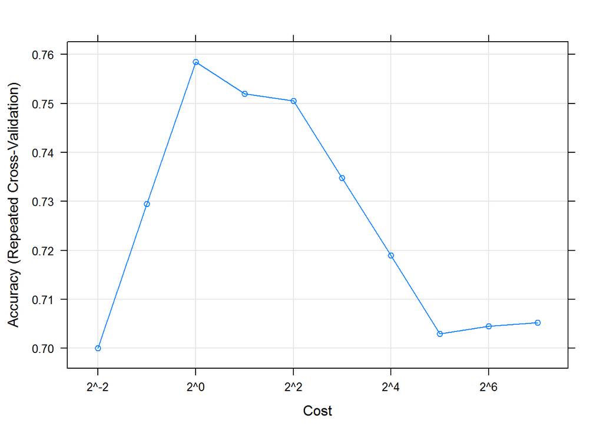

```r
plot(svmFit, scales = list(x = list(log = 2)))
```

```r
svmFit <- train(Class ~ .,
                data = germanCreditTrain,
                method = "svmRadial",
                preProcess = c("center", "scale"),
                trControl = trainControl(method = "repeatedcv",
                                         number = 10,
                                         repeats = 5),
                tuneGrid = expand.grid(C = seq(0.25, 128, length.out = 5),
                                       sigma = seq(0.01, 0.04, length.out = 5)))

svmFit$results
```

```
##           C  sigma Accuracy     Kappa AccuracySD    KappaSD
## 1    0.2500 0.0100  0.70000 0.0000000 0.00000000 0.00000000
## 6   32.1875 0.0100  0.71175 0.3105134 0.04541546 0.10239013
## 11  64.1250 0.0100  0.70025 0.2903035 0.04590988 0.09844911
## 16  96.0625 0.0100  0.69775 0.2853730 0.04822685 0.10194940
## 21 128.0000 0.0100  0.69475 0.2788408 0.05038690 0.11069425
## 2    0.2500 0.0175  0.70000 0.0000000 0.00000000 0.00000000
## 7   32.1875 0.0175  0.70650 0.2975958 0.04339249 0.09954017
## 12  64.1250 0.0175  0.70375 0.2890212 0.04671956 0.10623423
## 17  96.0625 0.0175  0.70375 0.2904999 0.04589320 0.10391123
## 22 128.0000 0.0175  0.70350 0.2907759 0.04538947 0.10253513
## 3    0.2500 0.0250  0.70000 0.0000000 0.00000000 0.00000000
## 8   32.1875 0.0250  0.71750 0.3052728 0.04278267 0.10440123
## 13  64.1250 0.0250  0.71575 0.3017458 0.04239408 0.10476975
## 18  96.0625 0.0250  0.71575 0.3017458 0.04239408 0.10476975
## 23 128.0000 0.0250  0.71575 0.3017458 0.04239408 0.10476975
## 4    0.2500 0.0325  0.70000 0.0000000 0.00000000 0.00000000
## 9   32.1875 0.0325  0.72875 0.3208120 0.04182157 0.10413467
## 14  64.1250 0.0325  0.72775 0.3194797 0.04197682 0.10361906
## 19  96.0625 0.0325  0.72775 0.3194797 0.04197682 0.10361906
## 24 128.0000 0.0325  0.72775 0.3194797 0.04197682 0.10361906
## 5    0.2500 0.0400  0.70000 0.0000000 0.00000000 0.00000000
## 10  32.1875 0.0400  0.73400 0.3201275 0.04033027 0.10560840
## 15  64.1250 0.0400  0.73400 0.3201275 0.04033027 0.10560840
## 20  96.0625 0.0400  0.73400 0.3201275 0.04033027 0.10560840
## 25 128.0000 0.0400  0.73400 0.3201275 0.04033027 0.10560840
```

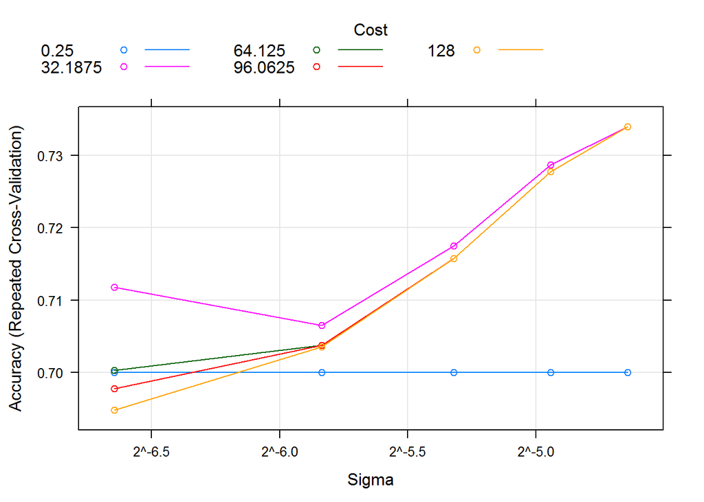

```r
plot(svmFit, scales = list(x = list(log = 2)))
```

```r
print(svmFit)
```

```
## Support Vector Machines with Radial Basis Function Kernel
##
## 800 samples
##  44 predictor
##   2 classes: 'Bad', 'Good'
##
## Pre-processing: centered (44), scaled (44)
## Resampling: Cross-Validated (10 fold, repeated 5 times)
## Summary of sample sizes: 720, 720, 720, 720, 720, 720, ...
## Resampling results across tuning parameters:
##
##   C         sigma   Accuracy  Kappa
##     0.2500  0.0100  0.70000   0.0000000
##     0.2500  0.0175  0.70000   0.0000000
##     0.2500  0.0250  0.70000   0.0000000
##     0.2500  0.0325  0.70000   0.0000000
##     0.2500  0.0400  0.70000   0.0000000
##    32.1875  0.0100  0.71175   0.3105134
##    32.1875  0.0175  0.70650   0.2975958
##    32.1875  0.0250  0.71750   0.3052728
##    32.1875  0.0325  0.72875   0.3208120
##    32.1875  0.0400  0.73400   0.3201275
##    64.1250  0.0100  0.70025   0.2903035
##    64.1250  0.0175  0.70375   0.2890212
##    64.1250  0.0250  0.71575   0.3017458
##    64.1250  0.0325  0.72775   0.3194797
##    64.1250  0.0400  0.73400   0.3201275
##    96.0625  0.0100  0.69775   0.2853730
##    96.0625  0.0175  0.70375   0.2904999
##    96.0625  0.0250  0.71575   0.3017458
##    96.0625  0.0325  0.72775   0.3194797
##    96.0625  0.0400  0.73400   0.3201275
##   128.0000  0.0100  0.69475   0.2788408
##   128.0000  0.0175  0.70350   0.2907759
##   128.0000  0.0250  0.71575   0.3017458
##   128.0000  0.0325  0.72775   0.3194797
##   128.0000  0.0400  0.73400   0.3201275
##
## Accuracy was used to select the optimal model using the largest value.
## The final values used for the model were sigma = 0.04 and C = 32.1875.
```

**GERMAN CREDIT LOGISTIC FIT**

```r
logisticFit <- train(Class ~ .,
                     data = germanCreditTrain,
                     method = "glm",
                     trControl = trainControl(method = "repeatedcv",
                                              number = 10,
                                              repeats = 5))
```

[output not shown]

[output cut: 94 more lines]

[output not shown]

```r
summary(logisticFit)
```

```
##
## Call:
## NULL
##
## Deviance Residuals:
##     Min       1Q   Median       3Q      Max
## -2.7184  -0.7338   0.3785   0.7451   2.4189
##
## Coefficients: (3 not defined because of singularities)
##                                          Estimate Std. Error z value
## (Intercept)                             5.250e+00  1.559e+00   3.367
## Duration                               -2.191e-02  1.031e-02  -2.125
## Amount                                 -1.870e-04  4.968e-05  -3.765
## InstallmentRatePercentage              -3.659e-01  9.750e-02  -3.753
## ResidenceDuration                      -5.553e-02  9.733e-02  -0.571
## Age                                     1.535e-02  9.962e-03   1.541
## NumberExistingCredits                  -3.162e-01  2.147e-01  -1.472
## NumberPeopleMaintenance                -1.752e-01  2.708e-01  -0.647
## Telephone                              -3.190e-01  2.241e-01  -1.423
## CheckingAccountStatus.lt.0             -1.724e+00  2.583e-01  -6.673
## CheckingAccountStatus.0.to.200         -1.373e+00  2.608e-01  -5.266
## CheckingAccountStatus.gt.200           -9.774e-01  4.072e-01  -2.400
## CheckingAccountStatus.none                     NA         NA      NA
## CreditHistory.ThisBank.AllPaid         -4.199e-01  6.141e-01  -0.684
## CreditHistory.PaidDuly                  6.624e-01  4.886e-01   1.356
## CreditHistory.Delay                     1.248e+00  5.412e-01   2.307
## CreditHistory.Critical                  1.445e+00  4.997e-01   2.892
## Purpose.NewCar                         -1.061e+00  4.290e-01  -2.474
## Purpose.UsedCar                         1.032e+00  5.519e-01   1.871
## Purpose.Furniture.Equipment            -5.406e-02  4.615e-01  -0.117
## Purpose.Radio.Television               -1.829e-01  4.353e-01  -0.420
## Purpose.Education                      -1.208e+00  5.590e-01  -2.161
## Purpose.Business                       -3.703e-01  5.171e-01  -0.716
## SavingsAccountBonds.lt.100             -1.803e+00  6.739e-01  -2.676
## SavingsAccountBonds.100.to.500         -1.616e+00  7.223e-01  -2.237
## SavingsAccountBonds.500.to.1000        -1.860e+00  7.817e-01  -2.380
## SavingsAccountBonds.Unknown            -1.010e+00  7.118e-01  -1.419
## EmploymentDuration.lt.1                -2.490e-01  4.758e-01  -0.523
## EmploymentDuration.1.to.4               3.393e-02  4.594e-01   0.074
## EmploymentDuration.4.to.7               9.583e-01  5.049e-01   1.898
```

[output cut: 56 more lines]

```
## Housing.Own                            0.582068
## Housing.ForFree                              NA
## Job.UnskilledResident                  0.482188
## Job.SkilledEmployee                    0.373805
## Job.Management.SelfEmp.HighlyQualified 0.346023
## ---
## Signif. codes:  0 '***' 0.001 '**' 0.01 '*' 0.05 '.' 0.1 ' ' 1
##
## (Dispersion parameter for binomial family taken to be 1)
##
##     Null deviance: 977.38  on 799  degrees of freedom
## Residual deviance: 727.15  on 758  degrees of freedom
## AIC: 811.15
##
## Number of Fisher Scoring iterations: 5
```

There seem to be some offending columns that are prompting warnings. Lets try excluding them

```r
logisticFit <- train(Class ~ .,
                     data = germanCreditTrain %>% select(-CheckingAccountStatus.none,
                                                         -EmploymentDuration.Unemployed,
                                                         -Personal.Male.Married.Widowed),
                     method = "glm",
                     trControl = trainControl(method = "repeatedcv",
                                              number = 10,
                                              repeats = 5))
```

[output not shown]

[output cut: 94 more lines]

[output not shown]

```r
logisticFit$results
```

```
##   parameter Accuracy     Kappa AccuracySD   KappaSD
## 1      none   0.7495 0.3599755   0.044101 0.1179818
```

Now comparing models

```r
resamp <- resamples(list(SVM = svmFit, Logistic = logisticFit))
summary(resamp)
```

```
##
## Call:
## summary.resamples(object = resamp)
##
## Models: SVM, Logistic
## Number of resamples: 50
##
## Accuracy
##            Min. 1st Qu. Median   Mean 3rd Qu.   Max. NA's
## SVM      0.6000  0.7125 0.7375 0.7340  0.7625 0.8000    0
## Logistic 0.6625  0.7250 0.7500 0.7495  0.7750 0.8375    0
##
## Kappa
##                Min.   1st Qu.    Median      Mean   3rd Qu.      Max. NA's
## SVM      0.04761905 0.2367470 0.3213360 0.3201275 0.4135802 0.5000000    0
## Logistic 0.14556962 0.2616465 0.3674699 0.3599755 0.4319277 0.5987654    0
```

No statistical test required to see that the logsitic regression is as good as a more complex support vector machine Exercise 4.2

```r
data("permeability")
glimpse(permeability)
```

```
##  num [1:165, 1] 12.52 1.12 19.41 1.73 1.68 ...
##  - attr(*, "dimnames")=List of 2
##   ..$ : chr [1:165] "1" "2" "3" "4" ...
##   ..$ : chr "permeability"
```

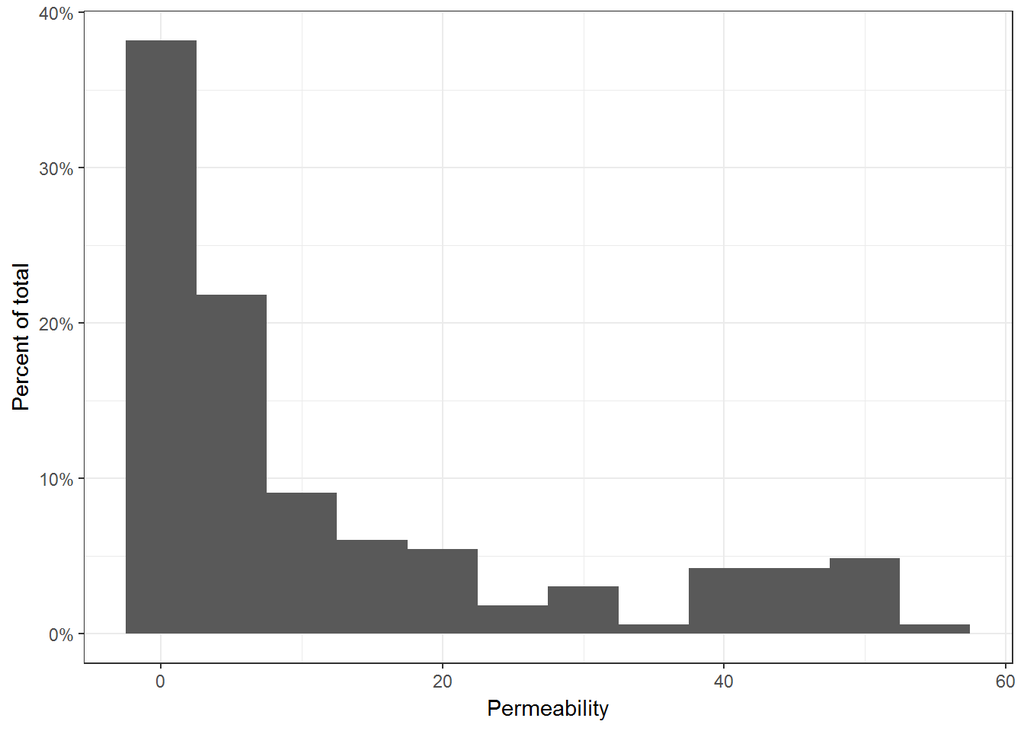

```r
ggplot(as.data.frame(permeability), aes(x = permeability)) +
  geom_histogram(aes(y = (..count..)/sum(..count..)), binwidth = 5) + # Need to grok this double dots!
  scale_y_continuous(labels = scales::percent) +
  labs(x = "Permeability",
       y = "Percent of total")
```

Exercise 4.3

```r
data("ChemicalManufacturingProcess")
glimpse(ChemicalManufacturingProcess)
```

```
## Observations: 176
## Variables: 58
## $ Yield                  <dbl> 38.00, 42.44, 42.03, 41.42, 42.49, 43.5...
## $ BiologicalMaterial01   <dbl> 6.25, 8.01, 8.01, 8.01, 7.47, 6.12, 7.4...
## $ BiologicalMaterial02   <dbl> 49.58, 60.97, 60.97, 60.97, 63.33, 58.3...
## $ BiologicalMaterial03   <dbl> 56.97, 67.48, 67.48, 67.48, 72.25, 65.3...
## $ BiologicalMaterial04   <dbl> 12.74, 14.65, 14.65, 14.65, 14.02, 15.1...
## $ BiologicalMaterial05   <dbl> 19.51, 19.36, 19.36, 19.36, 17.91, 21.7...
## $ BiologicalMaterial06   <dbl> 43.73, 53.14, 53.14, 53.14, 54.66, 51.2...
## $ BiologicalMaterial07   <dbl> 100, 100, 100, 100, 100, 100, 100, 100,...
## $ BiologicalMaterial08   <dbl> 16.66, 19.04, 19.04, 19.04, 18.22, 18.3...
## $ BiologicalMaterial09   <dbl> 11.44, 12.55, 12.55, 12.55, 12.80, 12.1...
## $ BiologicalMaterial10   <dbl> 3.46, 3.46, 3.46, 3.46, 3.05, 3.78, 3.0...
## $ BiologicalMaterial11   <dbl> 138.09, 153.67, 153.67, 153.67, 147.61,...
## $ BiologicalMaterial12   <dbl> 18.83, 21.05, 21.05, 21.05, 21.05, 20.7...
```

[output cut: 45 more lines]

Check for degenerate features

```r
length(nearZeroVar(ChemicalManufacturingProcess)) > 0
```

```
## [1] TRUE
```

```r
chemManufactProcessData <- ChemicalManufacturingProcess %>% select(-nearZeroVar(ChemicalManufacturingProcess))
```

Quick check on overall extent of missingness

```r
sum(is.na(chemManufactProcessData))
```

```
## [1] 106
```

```r
chemManufactProcessData %>% select_if(function(x) any(is.na(x))) %>%
                            summarize_all(funs(sum(is.na(.))*100/length(.)))
```

```
##   ManufacturingProcess01 ManufacturingProcess02 ManufacturingProcess03
## 1              0.5681818               1.704545               8.522727
##   ManufacturingProcess04 ManufacturingProcess05 ManufacturingProcess06
## 1              0.5681818              0.5681818               1.136364
##   ManufacturingProcess07 ManufacturingProcess08 ManufacturingProcess10
## 1              0.5681818              0.5681818               5.113636
##   ManufacturingProcess11 ManufacturingProcess12 ManufacturingProcess14
## 1               5.681818              0.5681818              0.5681818
##   ManufacturingProcess22 ManufacturingProcess23 ManufacturingProcess24
## 1              0.5681818              0.5681818              0.5681818
##   ManufacturingProcess25 ManufacturingProcess26 ManufacturingProcess27
## 1               2.840909               2.840909               2.840909
##   ManufacturingProcess28 ManufacturingProcess29 ManufacturingProcess30
## 1               2.840909               2.840909               2.840909
##   ManufacturingProcess31 ManufacturingProcess33 ManufacturingProcess34
## 1               2.840909               2.840909               2.840909
##   ManufacturingProcess35 ManufacturingProcess36 ManufacturingProcess40
## 1               2.840909               2.840909              0.5681818
##   ManufacturingProcess41
## 1              0.5681818
```

```r
naImputer <- preProcess(chemManufactProcessData,
                        method = "knnImpute",
                        trControl = trainControl(method = "repeatedcv",
                                                 number = 10,
                                                 repeats = 5),
                        tuneGrid = data.frame(k = 2:10))

chemManufactProcessData <- predict(naImputer, chemManufactProcessData)
if (sum(is.na(chemManufactProcessData)) == 0) {
  cat("Success! No more missing Values\n")
}
```

```
## Success! No more missing Values
```

Check for highly correlated features

```r
highCorrVars <- chemManufactProcessData %>% cor() %>%
                                            findCorrelation(cutoff = 0.75)

chemManufactProcessData <- chemManufactProcessData %>% select(-highCorrVars)
glimpse(chemManufactProcessData)
```

```
## Observations: 176
## Variables: 37
## $ Yield                  <dbl> -1.17926733, 1.22636783, 1.00422585, 0....
## $ BiologicalMaterial03   <dbl> -2.68303622, -0.05623504, -0.05623504, ...
## $ BiologicalMaterial05   <dbl> 0.49419417, 0.41285548, 0.41285548, 0.4...
## $ BiologicalMaterial09   <dbl> -3.39628945, -0.72272251, -0.72272251, ...
## $ BiologicalMaterial10   <dbl> 1.1005296, 1.1005296, 1.1005296, 1.1005...
## $ BiologicalMaterial11   <dbl> -1.83865496, 1.39339475, 1.39339475, 1....
## $ ManufacturingProcess01 <dbl> 0.21541048, -6.14970280, -6.14970280, -...
## $ ManufacturingProcess02 <dbl> 0.5662872, -1.9692525, -1.9692525, -1.9...
## $ ManufacturingProcess03 <dbl> 0.37658102, 0.19799621, 0.10870380, 0.4...
## $ ManufacturingProcess04 <dbl> 0.56555981, -2.36697255, -3.16385635, -...
## $ ManufacturingProcess05 <dbl> -0.44593467, 0.99933318, 0.06246417, 0....
## $ ManufacturingProcess06 <dbl> -0.54149966, 0.96253831, -0.11177452, 2...
## $ ManufacturingProcess07 <dbl> -0.1596700, -0.9580199, 1.0378549, -0.9...
```

[output cut: 24 more lines]

Plot to see if there is any skew in the predictors

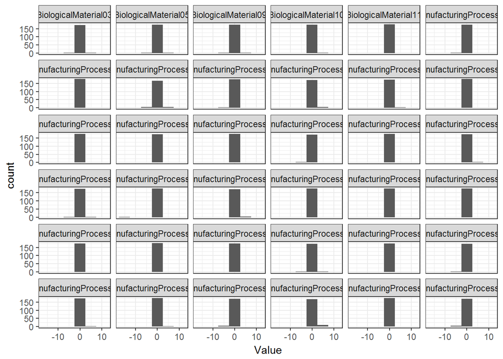

```r
chemManufactProcessData %>% gather("Variable", "Value", 2:37) %>%
                            ggplot(aes(x = Value)) +
                             geom_histogram(binwidth = 5) +
                             facet_wrap(~Variable)
```

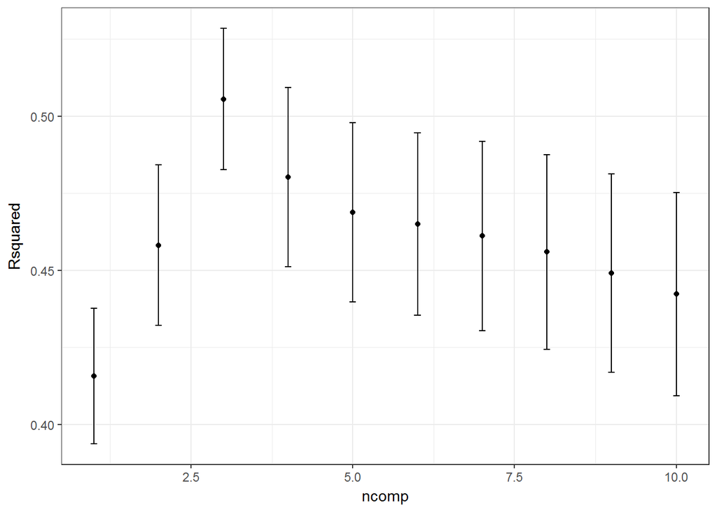

```r
plsProfileChemFit <- train(Yield ~ .,
                           data = chemManufactProcessData,
                           method = "pls",
                           preProcess = c("center", "scale"),
                           tuneLength = 10,
                           trControl = trainControl(method = "repeatedcv",
                                                    number = 10,
                                                    repeats = 5))
R2Values <- plsProfileChemFit$results %>% select(ncomp, Rsquared, RsquaredSD) %>%
                                          mutate(RsquaredSE = RsquaredSD/sqrt(length(plsProfileChemFit$control$index)))

ggplot(R2Values, aes(x = ncomp, y = Rsquared)) +
  geom_point() +
  geom_errorbar(aes(ymin = Rsquared - RsquaredSE, ymax = Rsquared + RsquaredSE), width = 0.1)
```

Now, we fit a succession of models, with little regard for model hyperparameters

```r
plsChemFit <- train(Yield ~ .,
                    data = chemManufactProcessData,
                    method = "pls",
                    preProcess = c("center", "scale"),
                    tuneLength = 10,
                    trControl = trainControl(method = "repeatedcv",
                                             number = 10,
                                             repeats = 5))

lmChemFit <- train(Yield ~ .,
                   data = chemManufactProcessData,
                   method = "lm",
                   preProcess = c("center", "scale"),
                   trControl = trainControl(method = "repeatedcv",
                                            number = 10,
                                            repeats = 5))
svmChemFit <- train(Yield ~ .,
                    data = chemManufactProcessData,
                    method = "svmLinear",
                    preProcess = c("center", "scale"),
                    tuneLength = 10,
                    trControl = trainControl(method = "repeatedcv",
                                             number = 10,
                                             repeats = 5))
rfChemFit <- train(Yield ~ .,
                   data = chemManufactProcessData,
                   method = "rf",
                   preProcess = c("center", "scale"),
                   tuneLength = 10,
                   trControl = trainControl(method = "repeatedcv",
                                            number = 10,
                                            repeats = 5))
```

Exercise 4.4

```r
data(oil)
glimpse(oilType)
```

```
##  Factor w/ 7 levels "A","B","C","D",..: 1 1 1 1 1 1 1 1 1 1 ...
```

This is a nice puzzle. It illustrates the heavy lifting that is done by createDataPartition()

```r
oilType %>% table() %>% prop.table()
```

```
## .
##          A          B          C          D          E          F
## 0.38541667 0.27083333 0.03125000 0.07291667 0.11458333 0.10416667
##          G
## 0.02083333
```

```r
sample(oilType) %>% table() %>% prop.table() # full sample
```

```
## .
##          A          B          C          D          E          F
## 0.38541667 0.27083333 0.03125000 0.07291667 0.11458333 0.10416667
##          G
## 0.02083333
```

Create a data partition with 60-40 split, using sample. We create 1000 such resamples and check the variability

```r
sampleSize <- floor(0.6*length(oilType))
numResamples <- 1000
randDataPartitions <- matrix(nrow = numResamples, ncol = 7)
colnames(randDataPartitions) <- LETTERS[1:7]

for (sample in 1:numResamples){
  randDataPartitions[sample, ] <- sample(oilType, size = sampleSize, replace = FALSE) %>%
                                  table() %>%
                                  prop.table()
}


trainingRows <- createDataPartition(oilType, p = 0.6, times = numResamples)

caretDataPartitions <- matrix(nrow = numResamples, ncol = 7)
colnames(caretDataPartitions) <- LETTERS[1:7]

for (sample in 1:numResamples) {
  caretDataPartitions[sample, ] <- oilType[trainingRows[[sample]]] %>%
                                   table() %>%
                                   prop.table()
}
```

Original Data

```r
oilType %>% table() %>% prop.table()
```

```
## .
##          A          B          C          D          E          F
## 0.38541667 0.27083333 0.03125000 0.07291667 0.11458333 0.10416667
##          G
## 0.02083333
```

Random sampling

```r
randDataPartitions %>% as.data.frame() %>%
                       summarize_all(funs(mean, sd))
```

```
##      A_mean    B_mean     C_mean    D_mean   E_mean    F_mean     G_mean
## 1 0.3864035 0.2707368 0.03124561 0.0724386 0.114386 0.1043158 0.02047368
##         A_sd       B_sd       C_sd       D_sd       E_sd       F_sd
## 1 0.04288873 0.03874872 0.01500765 0.02193981 0.02642007 0.02631189
##         G_sd
## 1 0.01207324
```

Stratified sampling using caret

```r
caretDataPartitions %>% as.data.frame() %>%
                        summarize_all(funs(mean, sd))
```

```
##      A_mean    B_mean     C_mean     D_mean    E_mean     F_mean
## 1 0.3770492 0.2622951 0.03278689 0.08196721 0.1147541 0.09836066
##       G_mean A_sd B_sd C_sd D_sd E_sd F_sd G_sd
## 1 0.03278689    0    0    0    0    0    0    0
```

There is no variability in the data partitions created by caret!